# Manufacturing Data Integration & Operational Analysis

This project integrates machine operating data, supplier characteristics, production-batch information, and product test results to investigate patterns associated with manufacturing performance. The analysis examines differences across machines, suppliers, and production batches before using unsupervised clustering to identify operating-condition profiles associated with substantially different product failure rates.

### Project Objective

The objective is to combine multiple manufacturing data sources into a unified analytical dataset and determine which production characteristics are most strongly associated with differences in product test outcomes.

### Data

The analysis integrates five datasets:

- Three machine datasets containing production-batch and operating measurements (`x1`, `x2`, `x3`, and `x4`)
- Supplier data containing supplier and material-density information for each production batch
- Product test results containing pass/fail outcomes for tested products

The datasets are integrated using production batch and individual product identifiers.

### Tools & Methods

**Python • Pandas • Matplotlib • Seaborn • scikit-learn • KMeans Clustering**

Methods include data integration, exploratory data analysis, correlation analysis, failure-rate analysis, feature standardization, KMeans clustering, and silhouette analysis.

## Import

```python
# Core data and visualization libraries
import pandas as pd
import matplotlib.pyplot as plt
import seaborn as sns

# Machine learning
from sklearn.preprocessing import StandardScaler
from sklearn.cluster import KMeans
from sklearn.metrics import silhouette_score
```

## Machine Data Exploration

The datasets are first examined individually to understand their structure, data quality, distributions, and differences in operating behavior. The analysis then compares production batches and operating variables across the three machines before combining the datasets for further analysis.

```python
# Load production data from each of the three manufacturing machines
m01_df = pd.read_csv("data/machine_01.csv")
m02_df = pd.read_csv("data/machine_02.csv")
m03_df = pd.read_csv("data/machine_03.csv")
```

### Dataset Structure and Data Quality

Before beginning the analysis, the three machine datasets were reviewed for dimensions, column types, unique values, and missing data to verify their structure and identify potential data-quality issues.

```python
# Compare the dimensions of the three machine datasets
machine_dimensions = pd.DataFrame({
    "Machine": ["Machine 1", "Machine 2", "Machine 3"],
    "Rows": [m01_df.shape[0], m02_df.shape[0], m03_df.shape[0]],
    "Columns": [m01_df.shape[1], m02_df.shape[1], m03_df.shape[1]]
})

machine_dimensions
```

|  | Machine | Rows | Columns |
| --- | --- | --- | --- |
| 0 | Machine 1 | 5152 | 7 |
| 1 | Machine 2 | 5119 | 7 |
| 2 | Machine 3 | 4458 | 7 |

### Column Structure

The three machine datasets use the same schema. The structure was reviewed to confirm consistent column names and data types before the datasets were combined.

```python
# Review the shared schema and confirm data types across the machine datasets
schema_comparison = pd.DataFrame({
    "Machine 1": m01_df.dtypes,
    "Machine 2": m02_df.dtypes,
    "Machine 3": m03_df.dtypes
})

schema_comparison
```

|  | Machine 1 | Machine 2 | Machine 3 |
| --- | --- | --- | --- |
| ID | str | str | str |
| Batch | int64 | int64 | int64 |
| s_id | int64 | int64 | int64 |
| x1 | float64 | float64 | float64 |
| x2 | float64 | float64 | float64 |
| x3 | float64 | float64 | float64 |
| x4 | float64 | float64 | float64 |

```python
# Compare unique values and missing values across the three machine datasets
data_quality = pd.concat(
    {
        "Machine 1": pd.DataFrame({
            "Unique Values": m01_df.nunique(),
            "Missing Values": m01_df.isna().sum()
        }),
        "Machine 2": pd.DataFrame({
            "Unique Values": m02_df.nunique(),
            "Missing Values": m02_df.isna().sum()
        }),
        "Machine 3": pd.DataFrame({
            "Unique Values": m03_df.nunique(),
            "Missing Values": m03_df.isna().sum()
        })
    },
    axis=1
)

data_quality
```

|  | Machine 1 Unique Values | Machine 1 Missing Values | Machine 2 Unique Values | Machine 2 Missing Values | Machine 3 Unique Values | Machine 3 Missing Values |
| --- | --- | --- | --- | --- | --- | --- |
| ID | 5152 | 0 | 5119 | 0 | 4458 | 0 |
| Batch | 50 | 0 | 50 | 0 | 41 | 0 |
| s_id | 149 | 0 | 133 | 0 | 141 | 0 |
| x1 | 5152 | 0 | 5119 | 0 | 4458 | 0 |
| x2 | 5152 | 0 | 5119 | 0 | 4458 | 0 |
| x3 | 5152 | 0 | 5119 | 0 | 4458 | 0 |
| x4 | 5152 | 0 | 5119 | 0 | 4458 | 0 |

### Operating Variable Distributions

The distributions of the four continuous operating variables (`x1` through `x4`) were compared across the three machines to identify differences in operating conditions and potential multimodal patterns.

### Continuous Variables

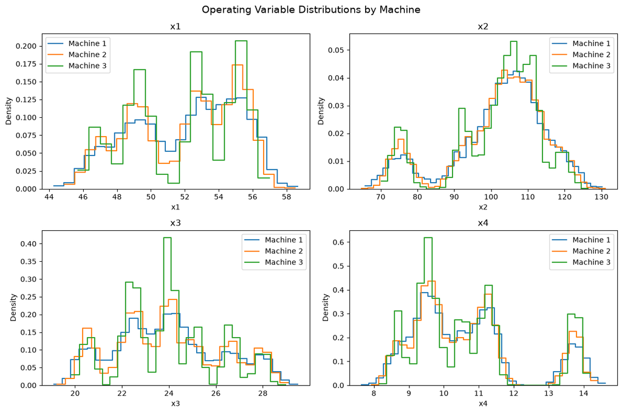

```python
# Compare operating-variable distributions across the three machines
machine_data = {
    "Machine 1": m01_df,
    "Machine 2": m02_df,
    "Machine 3": m03_df
}

operating_variables = ["x1", "x2", "x3", "x4"]

fig, axes = plt.subplots(2, 2, figsize=(12, 8))

for ax, variable in zip(axes.flatten(), operating_variables):
    for machine, df in machine_data.items():
        sns.histplot(
            data=df,
            x=variable,
            stat="density",
            element="step",
            fill=False,
            label=machine,
            ax=ax
        )

    ax.set_title(variable)
    ax.legend()

plt.suptitle("Operating Variable Distributions by Machine", fontsize=14)
plt.tight_layout()
plt.show()
```

**Distribution Summary:** The three machines operate across broadly similar ranges for all four operating variables, but the distributions are not identical. Machine 3 shows more concentrated peaks in several measurements, while Machines 1 and 2 generally follow similar distribution patterns. All four variables exhibit multiple peaks, suggesting that the operating measurements may reflect distinct production conditions or process groupings rather than a single uniform operating state.

### Production Batch Coverage

Production batches were compared across the three machines to identify differences in batch coverage before combining the machine datasets.

```python
# Compare batch coverage across the three machines
batch_coverage = pd.DataFrame({
    "Machine 1": m01_df.groupby("Batch").size(),
    "Machine 2": m02_df.groupby("Batch").size(),
    "Machine 3": m03_df.groupby("Batch").size()
}).fillna(0).astype(int)

batch_coverage
```

| Batch | Machine 1 | Machine 2 | Machine 3 |
| --- | --- | --- | --- |
| 1 | 70 | 102 | 85 |
| 2 | 131 | 119 | 120 |
| 3 | 100 | 99 | 103 |
| 4 | 68 | 81 | 102 |
| 5 | 100 | 120 | 141 |
| 6 | 103 | 101 | 106 |
| 7 | 121 | 98 | 0 |
| 8 | 111 | 116 | 0 |
| 9 | 105 | 91 | 119 |
| 10 | 111 | 107 | 0 |
| 11 | 101 | 104 | 0 |
| 12 | 135 | 105 | 140 |
| 13 | 119 | 88 | 110 |
| 14 | 81 | 83 | 94 |
| 15 | 71 | 72 | 76 |
| 16 | 93 | 96 | 94 |
| 17 | 99 | 64 | 100 |
| 18 | 93 | 110 | 0 |
| 19 | 109 | 105 | 127 |
| 20 | 97 | 114 | 100 |
| 21 | 97 | 119 | 141 |
| 22 | 128 | 97 | 112 |
| 23 | 58 | 107 | 84 |
| 24 | 53 | 76 | 103 |
| 25 | 98 | 114 | 0 |
| 26 | 72 | 81 | 113 |
| 27 | 127 | 130 | 109 |
| 28 | 75 | 93 | 72 |
| 29 | 134 | 119 | 117 |
| 30 | 99 | 95 | 0 |
| 31 | 73 | 82 | 106 |
| 32 | 101 | 100 | 127 |
| 33 | 140 | 100 | 127 |
| 34 | 127 | 114 | 121 |
| 35 | 76 | 82 | 77 |
| 36 | 149 | 110 | 110 |
| 37 | 122 | 107 | 127 |
| 38 | 67 | 96 | 108 |
| 39 | 89 | 97 | 0 |
| 40 | 148 | 106 | 111 |
| 41 | 125 | 117 | 120 |
| 42 | 106 | 117 | 122 |
| 43 | 106 | 133 | 133 |
| 44 | 114 | 107 | 102 |
| 45 | 112 | 120 | 112 |
| 46 | 119 | 115 | 115 |
| 47 | 107 | 89 | 53 |
| 48 | 112 | 108 | 115 |
| 49 | 91 | 117 | 104 |
| 50 | 109 | 96 | 0 |

```python
# Identify production batches not represented on each machine
missing_batches = {
    machine: batch_coverage.index[batch_coverage[machine] == 0].tolist()
    for machine in batch_coverage.columns
}

missing_batches
```

```
{'Machine 1': [],
 'Machine 2': [],
 'Machine 3': [7, 8, 10, 11, 18, 25, 30, 39, 50]}
```

**Batch Coverage Summary:** Machines 1 and 2 contain observations from all 50 production batches. Machine 3 contains data from 41 batches, with batches 7, 8, 10, 11, 18, 25, 30, 39, and 50 not represented. This difference in batch coverage should be considered when comparing operating behavior across machines.

### Operating Variable Summary Statistics

Summary statistics for the four operating variables were compared across machines to quantify differences in their central tendency and variability.

```python
# Compare summary statistics for operating variables across machines
operating_summary = pd.concat({
    "Machine 1": m01_df[["x1", "x2", "x3", "x4"]].describe(),
    "Machine 2": m02_df[["x1", "x2", "x3", "x4"]].describe(),
    "Machine 3": m03_df[["x1", "x2", "x3", "x4"]].describe()
})

operating_summary
```

|  |  | x1 | x2 | x3 | x4 |
| --- | --- | --- | --- | --- | --- |
| Machine 1 | count | 5152.000000 | 5152.000000 | 5152.000000 | 5152.000000 |
|  | mean | 51.998218 | 102.207011 | 23.947216 | 10.628436 |
|  | std | 3.151912 | 12.888171 | 2.269325 | 1.542291 |
|  | min | 44.275379 | 65.810729 | 19.095832 | 7.644190 |
|  | 25% | 49.335776 | 96.610288 | 22.334048 | 9.479969 |
|  | 50% | 52.536206 | 104.487824 | 23.855690 | 10.356002 |
|  | 75% | 54.662490 | 110.609442 | 25.448356 | 11.318120 |
|  | max | 58.647186 | 130.228828 | 29.477213 | 14.612911 |
| Machine 2 | count | 5119.000000 | 5119.000000 | 5119.000000 | 5119.000000 |
|  | mean | 51.989377 | 101.998905 | 23.982312 | 10.605275 |
|  | std | 3.095129 | 12.834348 | 2.275809 | 1.523140 |
|  | min | 44.896759 | 64.774007 | 19.232164 | 7.934064 |
|  | 25% | 49.240567 | 96.325502 | 22.372944 | 9.492226 |
|  | 50% | 52.610949 | 104.357308 | 23.894465 | 10.329911 |
|  | 75% | 54.785418 | 110.672960 | 25.546656 | 11.286062 |
|  | max | 58.503441 | 131.009046 | 29.093229 | 14.400437 |
| Machine 3 | count | 4458.000000 | 4458.000000 | 4458.000000 | 4458.000000 |
|  | mean | 51.857672 | 101.650057 | 23.927679 | 10.602371 |
|  | std | 3.022646 | 12.243012 | 2.035196 | 1.554708 |
|  | min | 45.690397 | 70.192150 | 19.865338 | 8.155668 |
|  | 25% | 49.228020 | 95.381831 | 22.457249 | 9.475467 |
|  | 50% | 52.598712 | 104.712727 | 23.900193 | 10.351781 |
|  | 75% | 54.810528 | 110.050211 | 25.142293 | 11.301126 |
|  | max | 56.981029 | 126.332105 | 28.972747 | 14.182623 |

**Summary Statistics:** The three machines show very similar average operating conditions across all four variables. Mean values differ only slightly between machines, indicating that their overall operating centers are comparable. Variability is also generally similar, although Machine 3 shows somewhat lower standard deviations for `x2` and `x3` and narrower observed ranges for several variables. These results suggest that differences between machines are more apparent in the shape and concentration of their operating distributions than in their overall averages.

### Relationships Between Operating Variables

Correlations among the four operating variables were examined for each machine to determine whether the relationships between operating conditions differ across machines.

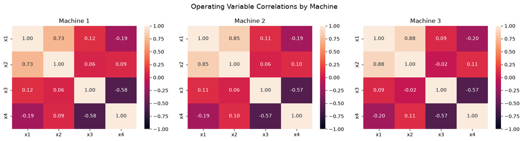

```python
# Compare correlations among operating variables across machines
fig, axes = plt.subplots(1, 3, figsize=(15, 4))

for ax, (machine, df) in zip(axes, machine_data.items()):
    correlation_matrix = df[operating_variables].corr()

    sns.heatmap(
        correlation_matrix,
        annot=True,
        fmt=".2f",
        vmin=-1,
        vmax=1,
        ax=ax
    )

    ax.set_title(machine)

plt.suptitle("Operating Variable Correlations by Machine", fontsize=14)
plt.tight_layout()
plt.show()
```

**Correlation Summary:** The relationships among the operating variables are largely consistent across all three machines. `x1` and `x2` show the strongest positive relationship, with correlations of 0.73, 0.85, and 0.88 for Machines 1, 2, and 3, respectively. `x3` and `x4` show a consistent moderate negative relationship of approximately -0.57 to -0.58. The remaining variable pairs have relatively weak correlations. Overall, the machines exhibit similar correlation structures, although the relationship between `x1` and `x2` is stronger for Machines 2 and 3.

## Combined Machine Dataset

To support comparisons across machines and production batches, the three machine-level datasets were labeled with a machine identifier and combined into a single dataset.

```python
# Add machine identifiers before combining the production datasets
m01_df["machine_id"] = 1
m02_df["machine_id"] = 2
m03_df["machine_id"] = 3

# Combine observations from all three machines
machine_df = pd.concat(
    [m01_df, m02_df, m03_df],
    ignore_index=True
)

machine_df.head()
```

|  | ID | Batch | s_id | x1 | x2 | x3 | x4 | machine_id |
| --- | --- | --- | --- | --- | --- | --- | --- | --- |
| 0 | B001-M01-S001 | 1 | 1 | 50.117118 | 102.167346 | 22.067812 | 13.889524 | 1 |
| 1 | B001-M01-S002 | 1 | 2 | 46.887333 | 112.266102 | 23.197330 | 13.064709 | 1 |
| 2 | B001-M01-S003 | 1 | 3 | 50.132744 | 103.674908 | 22.319933 | 13.647482 | 1 |
| 3 | B001-M01-S004 | 1 | 4 | 48.501042 | 107.143156 | 22.162947 | 14.077758 | 1 |
| 4 | B001-M01-S005 | 1 | 5 | 49.690442 | 102.120283 | 22.248696 | 13.728666 | 1 |

## Supplier and Batch Analysis

Supplier-level production data were incorporated to examine differences in material density across suppliers and production batches. The supplier data were then integrated with the machine dataset to explore how supplier characteristics relate to machine operating conditions.

```python
# Load supplier and batch data
batch_df = pd.read_csv("data/supplier_data.csv")
```

### Supplier Dataset Overview

The supplier dataset contains one record for each of 50 production batches, identifying the supplier associated with each batch and the corresponding material density.

```python
# Review the structure and completeness of the supplier dataset
print(f"Dataset shape: {batch_df.shape}")

print("\nData types:")
print(batch_df.dtypes)

print("\nUnique values:")
print(batch_df.nunique())

print("\nMissing values:")
print(batch_df.isna().sum())

batch_df.head()
```

```
Dataset shape: (50, 3)

Data types:
Batch         int64
Supplier        str
Density     float64
dtype: object

Unique values:
Batch       50
Supplier     2
Density     50
dtype: int64

Missing values:
Batch       0
Supplier    0
Density     0
dtype: int64
```

|  | Batch | Supplier | Density |
| --- | --- | --- | --- |
| 0 | 1 | B | 10.388587 |
| 1 | 2 | A | 9.296880 |
| 2 | 3 | A | 9.565636 |
| 3 | 4 | B | 10.005387 |
| 4 | 5 | A | 9.339177 |

### Supplier Density Patterns

Material density was compared across suppliers and production batches to identify differences in consistency and potential changes over the production sequence.

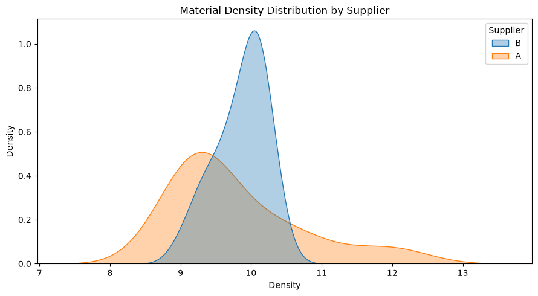

```python
# Compare density distributions across suppliers
plt.figure(figsize=(9, 5))

sns.kdeplot(
    data=batch_df,
    x="Density",
    hue="Supplier",
    fill=True,
    common_norm=False,
    alpha=0.35
)

plt.title("Material Density Distribution by Supplier")
plt.xlabel("Density")
plt.ylabel("Density")
plt.tight_layout()
plt.show()
```

**Supplier Density Summary:** Supplier B shows a more concentrated density distribution, indicating greater consistency across its production batches. Supplier A exhibits substantially greater variability, including several batches with higher density measurements.

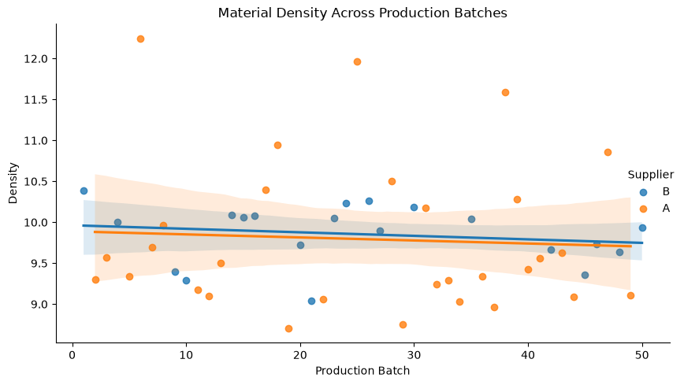

```python
# Examine density patterns across production batches by supplier
sns.lmplot(
    data=batch_df,
    x="Batch",
    y="Density",
    hue="Supplier",
    height=5,
    aspect=1.6
)

plt.title("Material Density Across Production Batches")
plt.xlabel("Production Batch")
plt.ylabel("Density")
plt.tight_layout()
plt.show()
```

**Batch Pattern Summary:** Density shows only a slight downward pattern across production batches for both suppliers. Supplier B remains relatively tightly clustered throughout the production sequence, while Supplier A shows substantially greater batch-to-batch variability.

### Integrated Production Dataset

Supplier and material-density information was joined to the machine operating data using the production batch identifier, creating a unified dataset for analyzing supplier and machine operating patterns together.

```python
# Integrate supplier information with machine operating data
dfa = pd.merge(
    machine_df,
    batch_df,
    on="Batch"
)

dfa.head()
```

|  | ID | Batch | s_id | x1 | x2 | x3 | x4 | machine_id | Supplier | Density |
| --- | --- | --- | --- | --- | --- | --- | --- | --- | --- | --- |
| 0 | B001-M01-S001 | 1 | 1 | 50.117118 | 102.167346 | 22.067812 | 13.889524 | 1 | B | 10.388587 |
| 1 | B001-M01-S002 | 1 | 2 | 46.887333 | 112.266102 | 23.197330 | 13.064709 | 1 | B | 10.388587 |
| 2 | B001-M01-S003 | 1 | 3 | 50.132744 | 103.674908 | 22.319933 | 13.647482 | 1 | B | 10.388587 |
| 3 | B001-M01-S004 | 1 | 4 | 48.501042 | 107.143156 | 22.162947 | 14.077758 | 1 | B | 10.388587 |
| 4 | B001-M01-S005 | 1 | 5 | 49.690442 | 102.120283 | 22.248696 | 13.728666 | 1 | B | 10.388587 |

### Operating Conditions by Supplier

Machine operating variables were compared across suppliers to determine whether supplier-related production batches exhibit different operating patterns.

```python
# Compare operating-variable statistics across suppliers
supplier_operating_summary = (
    dfa.groupby("Supplier")[["x1", "x2", "x3", "x4"]]
       .agg(["mean", "std"])
       .round(2)
)

supplier_operating_summary
```

| Supplier | x1 mean | x1 std | x2 mean | x2 std | x3 mean | x3 std | x4 mean | x4 std |
| --- | --- | --- | --- | --- | --- | --- | --- | --- |
| A | 51.69 | 3.11 | 101.49 | 12.96 | 24.04 | 2.18 | 10.66 | 1.60 |
| B | 52.38 | 3.02 | 102.74 | 12.16 | 23.82 | 2.24 | 10.54 | 1.43 |

**Operating Condition Summary:** Average machine operating conditions are broadly similar across Suppliers A and B. Supplier B shows slightly higher mean values for x1 and x2, while Supplier A is slightly higher for x3 and x4. Variability is also comparable across suppliers, suggesting that supplier differences in material density are not accompanied by large shifts in the measured machine operating conditions.

## Product Test Results

Drop-test results were incorporated to evaluate production outcomes and identify patterns in passing and failing observations across test groups.

```python
# Load product test results
test_df = pd.read_csv("data/test_results.csv")
```

### Test Results Dataset Overview

The test-results dataset was reviewed for structure, completeness, and outcome coverage before being integrated with the production data.

```python
# Review the structure and completeness of the test-results dataset
print(f"Dataset shape: {test_df.shape}")

print("\nData types:")
print(test_df.dtypes)

print("\nUnique values:")
print(test_df.nunique())

print("\nMissing values:")
print(test_df.isna().sum())

test_df.head()
```

```
Dataset shape: (1412, 3)

Data types:
ID                 str
test_group_id      str
Result           int64
dtype: object

Unique values:
ID               1412
test_group_id     141
Result              2
dtype: int64

Missing values:
ID               0
test_group_id    0
Result           0
dtype: int64
```

|  | ID | test_group_id | Result |
| --- | --- | --- | --- |
| 0 | B001-M01-S056 | A-0 | 1 |
| 1 | B001-M01-S002 | A-0 | 1 |
| 2 | B001-M01-S049 | A-0 | 1 |
| 3 | B001-M01-S030 | A-0 | 0 |
| 4 | B001-M01-S048 | A-0 | 1 |

### Test Outcomes Across Test Groups

Pass and fail counts were compared across test groups to identify groups with elevated failure activity.

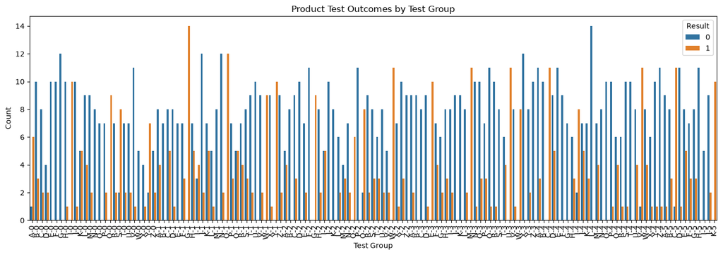

```python
# Compare test outcomes across test groups
plt.figure(figsize=(14, 5))

sns.countplot(
    data=test_df,
    x="test_group_id",
    hue="Result"
)

plt.title("Product Test Outcomes by Test Group")
plt.xlabel("Test Group")
plt.ylabel("Count")
plt.xticks(rotation=90)
plt.tight_layout()
plt.show()
```

**Test Outcome Summary:** Failure counts are not evenly distributed across test groups. Several groups show noticeable increases in failures, indicating that production outcomes vary across the tested groups and warrant further investigation alongside machine, supplier, and batch information.

### Final Integrated Analysis Dataset

Product test outcomes were joined to the existing machine and supplier data using the individual product identifier. Because test results are available for only a subset of production observations, the default inner join retains only records with matching test-result data.

```python
# Integrate product test outcomes with machine and supplier data
dfb = pd.merge(
    dfa,
    test_df,
    on="ID"
)

print(f"Matched production observations: {len(dfb):,}")

dfb.head()
```

```
Matched production observations: 1,412
```

|  | ID | Batch | s_id | x1 | x2 | x3 | x4 | machine_id | Supplier | Density | test_group_id | Result |
| --- | --- | --- | --- | --- | --- | --- | --- | --- | --- | --- | --- | --- |
| 0 | B001-M01-S002 | 1 | 2 | 46.887333 | 112.266102 | 23.197330 | 13.064709 | 1 | B | 10.388587 | A-0 | 1 |
| 1 | B001-M01-S024 | 1 | 24 | 51.531574 | 100.207219 | 22.281345 | 13.796810 | 1 | B | 10.388587 | A-0 | 1 |
| 2 | B001-M01-S030 | 1 | 30 | 48.306819 | 109.445722 | 22.910858 | 13.839830 | 1 | B | 10.388587 | A-0 | 0 |
| 3 | B001-M01-S038 | 1 | 38 | 52.058573 | 93.272568 | 21.937216 | 13.332882 | 1 | B | 10.388587 | A-0 | 1 |
| 4 | B001-M01-S048 | 1 | 48 | 50.564504 | 109.184587 | 22.083064 | 13.954942 | 1 | B | 10.388587 | A-0 | 1 |

### Test Results Integration Summary

Test outcomes vary across test groups, with several groups showing elevated failure counts. Integrating the test results with the machine and supplier data produced 1,412 matched production observations, creating the final dataset used to investigate whether failures are associated with specific machines, suppliers, batches, or operating conditions.

## Production Failure Analysis

The integrated production dataset was analyzed to identify whether test failures are concentrated among particular machines, suppliers, or production batches. Failure rates are used where appropriate so that groups with different numbers of tested observations can be compared more fairly.

### Failure Patterns by Machine

Failure rates were compared across machines to determine whether test outcomes differ after accounting for the number of tested observations associated with each machine.

```python
# Summarize test outcomes and failure rates by machine
machine_failure_summary = (
    dfb.groupby("machine_id")["Result"]
       .agg(
           tested="count",
           passed="sum"
       )
)

machine_failure_summary["failed"] = (
    machine_failure_summary["tested"]
    - machine_failure_summary["passed"]
)

machine_failure_summary["failure_rate"] = (
    machine_failure_summary["failed"]
    / machine_failure_summary["tested"]
)

machine_failure_summary.round(3)
```

| machine_id | tested | passed | failed | failure_rate |
| --- | --- | --- | --- | --- |
| 1 | 492 | 159 | 333 | 0.677 |
| 2 | 489 | 147 | 342 | 0.699 |
| 3 | 431 | 120 | 311 | 0.722 |

**Machine Failure Summary:** Failure rates are relatively high across all three machines, ranging from 67.7% to 72.2%. Machine 3 has the highest observed failure rate at 72.2%, followed by Machine 2 at 69.9% and Machine 1 at 67.7%. Although Machine 3 has fewer total failures because fewer observations were tested, its failure rate is actually the highest of the three machines. This demonstrates why failure rates provide a more meaningful comparison than raw failure counts when group sizes differ.

### Failure Patterns by Supplier

Failure rates were compared across suppliers to determine whether test outcomes differ between production batches associated with Suppliers A and B.

```python
# Summarize test outcomes and failure rates by supplier
supplier_failure_summary = (
    dfb.groupby("Supplier")["Result"]
       .agg(
           tested="count",
           passed="sum"
       )
)

supplier_failure_summary["failed"] = (
    supplier_failure_summary["tested"]
    - supplier_failure_summary["passed"]
)

supplier_failure_summary["failure_rate"] = (
    supplier_failure_summary["failed"]
    / supplier_failure_summary["tested"]
)

supplier_failure_summary.round(3)
```

| Supplier | tested | passed | failed | failure_rate |
| --- | --- | --- | --- | --- |
| A | 878 | 290 | 588 | 0.670 |
| B | 534 | 136 | 398 | 0.745 |

**Supplier Failure Summary:** Supplier A accounts for more failures in absolute terms, with 588 failures compared with 398 for Supplier B. However, Supplier A also has substantially more tested observations. When differences in sample size are considered, Supplier B has the higher failure rate at 74.5%, compared with 67.0% for Supplier A. This indicates that raw failure counts alone would give a misleading impression of supplier performance.

### Batch-Level Failure Patterns

Failure rates were calculated for each production batch to identify batches with unusually high or low failure activity and determine whether failures are concentrated within particular portions of the production data.

```python
# Calculate test outcomes and failure rates by production batch
batch_failure_summary = (
    dfb.groupby("Batch")["Result"]
       .agg(
           tested="count",
           passed="sum"
       )
)

batch_failure_summary["failed"] = (
    batch_failure_summary["tested"]
    - batch_failure_summary["passed"]
)

batch_failure_summary["failure_rate"] = (
    batch_failure_summary["failed"]
    / batch_failure_summary["tested"]
)

batch_failure_summary.round(3)
```

| Batch | tested | passed | failed | failure_rate |
| --- | --- | --- | --- | --- |
| 1 | 25 | 24 | 1 | 0.040 |
| 2 | 36 | 5 | 31 | 0.861 |
| 3 | 29 | 8 | 21 | 0.724 |
| 4 | 24 | 2 | 22 | 0.917 |
| 5 | 36 | 6 | 30 | 0.833 |
| 6 | 30 | 0 | 30 | 1.000 |
| 7 | 21 | 2 | 19 | 0.905 |
| 8 | 22 | 1 | 21 | 0.955 |
| 9 | 30 | 30 | 0 | 0.000 |
| 10 | 21 | 3 | 18 | 0.857 |
| 11 | 20 | 10 | 10 | 0.500 |
| 12 | 37 | 9 | 28 | 0.757 |
| 13 | 30 | 2 | 28 | 0.933 |
| 14 | 25 | 2 | 23 | 0.920 |
| 15 | 21 | 3 | 18 | 0.857 |
| 16 | 27 | 7 | 20 | 0.741 |
| 17 | 25 | 23 | 2 | 0.080 |
| 18 | 20 | 2 | 18 | 0.900 |
| 19 | 32 | 21 | 11 | 0.344 |
| 20 | 30 | 7 | 23 | 0.767 |
| 21 | 34 | 5 | 29 | 0.853 |
| 22 | 32 | 8 | 24 | 0.750 |
| 23 | 23 | 2 | 21 | 0.913 |
| 24 | 22 | 3 | 19 | 0.864 |
| 25 | 20 | 18 | 2 | 0.100 |
| 26 | 26 | 4 | 22 | 0.846 |
| 27 | 35 | 11 | 24 | 0.686 |
| 28 | 23 | 1 | 22 | 0.957 |
| 29 | 35 | 8 | 27 | 0.771 |
| 30 | 18 | 1 | 17 | 0.944 |
| 31 | 25 | 0 | 25 | 1.000 |
| 32 | 32 | 8 | 24 | 0.750 |
| 33 | 36 | 35 | 1 | 0.028 |
| 34 | 35 | 13 | 22 | 0.629 |
| 35 | 22 | 7 | 15 | 0.682 |
| 36 | 36 | 6 | 30 | 0.833 |
| 37 | 34 | 8 | 26 | 0.765 |
| 38 | 25 | 2 | 23 | 0.920 |
| 39 | 17 | 0 | 17 | 1.000 |
| 40 | 35 | 7 | 28 | 0.800 |
| 41 | 35 | 34 | 1 | 0.029 |
| 42 | 33 | 5 | 28 | 0.848 |
| 43 | 36 | 13 | 23 | 0.639 |
| 44 | 31 | 10 | 21 | 0.677 |
| 45 | 34 | 7 | 27 | 0.794 |
| 46 | 33 | 3 | 30 | 0.909 |
| 47 | 23 | 0 | 23 | 1.000 |
| 48 | 32 | 8 | 24 | 0.750 |
| 49 | 30 | 30 | 0 | 0.000 |
| 50 | 19 | 2 | 17 | 0.895 |

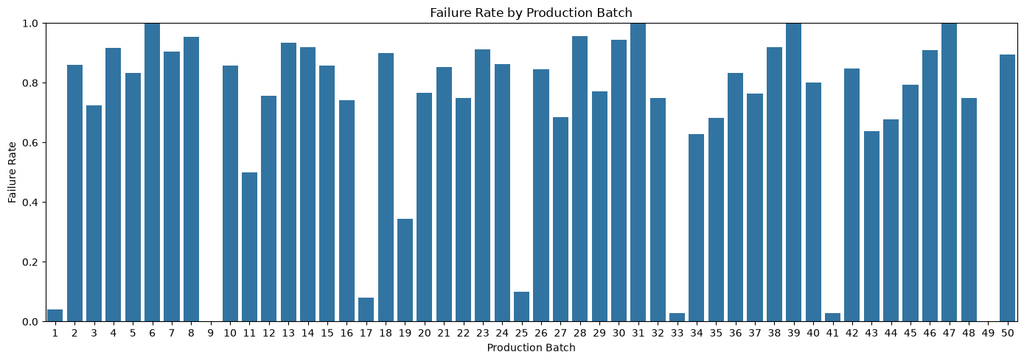

```python
# Visualize failure rates across production batches
batch_failure_plot = batch_failure_summary.reset_index()

plt.figure(figsize=(14, 5))

sns.barplot(
    data=batch_failure_plot,
    x="Batch",
    y="failure_rate"
)

plt.title("Failure Rate by Production Batch")
plt.xlabel("Production Batch")
plt.ylabel("Failure Rate")
plt.ylim(0, 1)
plt.tight_layout()
plt.show()
```

**Batch Failure Summary:** Failure rates vary substantially across production batches. Batches 6, 31, 39, and 47 experienced failures for all tested observations, while Batches 9 and 49 had no observed failures. Several additional batches had failure rates above 90%, while others remained below 10%. The magnitude of this variation suggests that production batch is more strongly associated with differences in test outcomes than the relatively modest differences observed across machines or suppliers.

### Batch Failure Patterns Across Machines

Batch-level failure rates were compared across machines to determine whether unusually high or low failure rates are consistent across the production process or concentrated within particular machine-batch combinations.

```python
# Calculate failure rates for each batch and machine combination
batch_machine_summary = (
    dfb.groupby(["Batch", "machine_id"])["Result"]
       .agg(
           tested="count",
           passed="sum"
       )
)

batch_machine_summary["failed"] = (
    batch_machine_summary["tested"]
    - batch_machine_summary["passed"]
)

batch_machine_summary["failure_rate"] = (
    batch_machine_summary["failed"]
    / batch_machine_summary["tested"]
)


# Summarize variation in failure rates across machines within each batch
batch_machine_variation = (
    batch_machine_summary
    .reset_index()
    .groupby("Batch")
    .agg(
        machines_tested=("machine_id", "count"),
        min_failure_rate=("failure_rate", "min"),
        max_failure_rate=("failure_rate", "max"),
        avg_failure_rate=("failure_rate", "mean")
    )
)

batch_machine_variation["rate_range"] = (
    batch_machine_variation["max_failure_rate"]
    - batch_machine_variation["min_failure_rate"]
)

batch_machine_variation.sort_values(
    "rate_range",
    ascending=False
).round(3)
```

| Batch | machines_tested | min_failure_rate | max_failure_rate | avg_failure_rate | rate_range |
| --- | --- | --- | --- | --- | --- |
| 15 | 3 | 0.571 | 1.000 | 0.857 | 0.429 |
| 35 | 3 | 0.429 | 0.857 | 0.679 | 0.429 |
| 19 | 3 | 0.200 | 0.583 | 0.328 | 0.383 |
| 12 | 3 | 0.643 | 1.000 | 0.778 | 0.357 |
| 4 | 3 | 0.667 | 1.000 | 0.889 | 0.333 |
| 37 | 3 | 0.583 | 0.917 | 0.767 | 0.333 |
| 29 | 3 | 0.615 | 0.909 | 0.781 | 0.294 |
| 24 | 3 | 0.714 | 1.000 | 0.838 | 0.286 |
| 22 | 3 | 0.636 | 0.917 | 0.740 | 0.280 |
| 21 | 3 | 0.727 | 1.000 | 0.835 | 0.273 |
| 43 | 3 | 0.500 | 0.769 | 0.628 | 0.269 |
| 5 | 3 | 0.750 | 1.000 | 0.845 | 0.250 |
| 14 | 3 | 0.750 | 1.000 | 0.917 | 0.250 |
| 3 | 3 | 0.556 | 0.800 | 0.719 | 0.244 |
| 32 | 3 | 0.667 | 0.900 | 0.756 | 0.233 |
| 2 | 3 | 0.769 | 1.000 | 0.862 | 0.231 |
| 7 | 2 | 0.778 | 1.000 | 0.889 | 0.222 |
| 18 | 2 | 0.778 | 1.000 | 0.889 | 0.222 |
| 25 | 2 | 0.000 | 0.222 | 0.111 | 0.222 |
| 48 | 3 | 0.600 | 0.818 | 0.745 | 0.218 |
| 42 | 3 | 0.700 | 0.917 | 0.842 | 0.217 |
| 17 | 3 | 0.000 | 0.200 | 0.067 | 0.200 |
| 23 | 3 | 0.800 | 1.000 | 0.933 | 0.200 |
| 26 | 3 | 0.714 | 0.909 | 0.833 | 0.195 |
| 45 | 3 | 0.727 | 0.917 | 0.790 | 0.189 |
| 13 | 3 | 0.818 | 1.000 | 0.939 | 0.182 |
| 36 | 3 | 0.727 | 0.909 | 0.831 | 0.182 |
| 46 | 3 | 0.818 | 1.000 | 0.909 | 0.182 |
| 27 | 3 | 0.600 | 0.769 | 0.679 | 0.169 |
| 38 | 3 | 0.833 | 1.000 | 0.911 | 0.167 |
| 28 | 3 | 0.857 | 1.000 | 0.952 | 0.143 |
| 1 | 3 | 0.000 | 0.143 | 0.048 | 0.143 |
| 40 | 3 | 0.727 | 0.857 | 0.795 | 0.130 |
| 20 | 3 | 0.700 | 0.818 | 0.765 | 0.118 |
| 30 | 2 | 0.889 | 1.000 | 0.944 | 0.111 |
| 16 | 3 | 0.667 | 0.778 | 0.741 | 0.111 |
| 10 | 2 | 0.800 | 0.909 | 0.855 | 0.109 |
| 8 | 2 | 0.909 | 1.000 | 0.955 | 0.091 |
| 41 | 3 | 0.000 | 0.083 | 0.028 | 0.083 |
| 33 | 3 | 0.000 | 0.083 | 0.028 | 0.083 |
| 34 | 3 | 0.583 | 0.667 | 0.629 | 0.083 |
| 44 | 3 | 0.636 | 0.700 | 0.679 | 0.064 |
| 50 | 2 | 0.889 | 0.900 | 0.894 | 0.011 |
| 11 | 2 | 0.500 | 0.500 | 0.500 | 0.000 |
| 6 | 3 | 1.000 | 1.000 | 1.000 | 0.000 |
| 9 | 3 | 0.000 | 0.000 | 0.000 | 0.000 |
| 31 | 3 | 1.000 | 1.000 | 1.000 | 0.000 |
| 39 | 2 | 1.000 | 1.000 | 1.000 | 0.000 |
| 47 | 3 | 1.000 | 1.000 | 1.000 | 0.000 |
| 49 | 3 | 0.000 | 0.000 | 0.000 | 0.000 |

**Machine-Batch Summary:** Failure rates vary across machines within some production batches, but the strongest batch-level patterns remain consistent across machines. Batches 6, 31, and 47 experienced 100% failure rates on all three machines, while Batch 39 had a 100% failure rate on both machines represented. In contrast, Batches 9 and 49 had no observed failures across any of the three machines. These consistent outcomes across multiple machines suggest that the substantial variation in test results is associated more strongly with production batch than with a single machine.

### Failure Analysis Summary

Failure rates are high across all three machines, with relatively modest differences between them. Supplier B has a higher failure rate than Supplier A despite accounting for fewer failures in absolute terms. The largest variation in test outcomes occurs across production batches, where failure rates range from 0% to 100%. Several extreme batch outcomes remain consistent across multiple machines, indicating that batch-level characteristics warrant greater attention than machine identity alone when investigating the observed production failures.

## Production Pattern Clustering

Unsupervised clustering was used to determine whether products with similar machine operating conditions form distinct production groups. The resulting clusters were then compared with observed test outcomes to evaluate whether particular operating-condition profiles are associated with higher or lower failure rates.

The clustering analysis uses only the four continuous machine operating variables (`x1`, `x2`, `x3`, and `x4`). Test results, machine identifiers, supplier information, and production batches are excluded from model fitting so that the clusters are based solely on similarities in operating conditions.

```python
# Select machine operating variables for clustering
cluster_features = ["x1", "x2", "x3", "x4"]

X_cluster = dfb[cluster_features].copy()

print(f"Observations used for clustering: {len(X_cluster):,}")
X_cluster.describe().round(2)
```

```
Observations used for clustering: 1,412
```

|  | x1 | x2 | x3 | x4 |
| --- | --- | --- | --- | --- |
| count | 1412.00 | 1412.00 | 1412.00 | 1412.00 |
| mean | 51.93 | 101.77 | 23.94 | 10.60 |
| std | 3.12 | 12.70 | 2.21 | 1.54 |
| min | 45.04 | 66.62 | 19.36 | 7.88 |
| 25% | 49.18 | 95.97 | 22.37 | 9.48 |
| 50% | 52.56 | 104.34 | 23.87 | 10.31 |
| 75% | 54.75 | 110.29 | 25.29 | 11.28 |
| max | 58.65 | 125.29 | 28.99 | 14.56 |

### Feature Standardization

The four operating variables are measured on different numeric scales. Before clustering, the variables were standardized so that each contributes comparably to the distance calculations used by the clustering algorithm.

```python
# Standardize operating variables before clustering
scaler = StandardScaler()

X_scaled = scaler.fit_transform(X_cluster)

X_scaled = pd.DataFrame(
    X_scaled,
    columns=cluster_features,
    index=X_cluster.index
)

X_scaled.describe().round(2)
```

|  | x1 | x2 | x3 | x4 |
| --- | --- | --- | --- | --- |
| count | 1412.00 | 1412.00 | 1412.00 | 1412.00 |
| mean | -0.00 | 0.00 | 0.00 | 0.00 |
| std | 1.00 | 1.00 | 1.00 | 1.00 |
| min | -2.21 | -2.77 | -2.07 | -1.76 |
| 25% | -0.88 | -0.46 | -0.71 | -0.73 |
| 50% | 0.20 | 0.20 | -0.03 | -0.19 |
| 75% | 0.90 | 0.67 | 0.61 | 0.44 |
| max | 2.15 | 1.85 | 2.28 | 2.57 |

### Selecting the Number of Clusters

Candidate cluster solutions were evaluated using both inertia and silhouette score. Inertia measures how tightly observations are grouped within clusters and is commonly evaluated using the elbow method. Silhouette score measures how well observations fit within their assigned cluster relative to neighboring clusters, providing an additional measure of cluster separation.

```python
# Evaluate candidate cluster solutions
cluster_results = []

for k in range(2, 13):
    model = KMeans(
        n_clusters=k,
        random_state=42,
        n_init=10
    )

    labels = model.fit_predict(X_scaled)

    cluster_results.append({
        "k": k,
        "inertia": model.inertia_,
        "silhouette_score": silhouette_score(X_scaled, labels)
    })

cluster_evaluation = pd.DataFrame(cluster_results)

cluster_evaluation.round(3)
```

|  | k | inertia | silhouette_score |
| --- | --- | --- | --- |
| 0 | 2 | 3431.940 | 0.402 |
| 1 | 3 | 1835.480 | 0.506 |
| 2 | 4 | 1288.952 | 0.533 |
| 3 | 5 | 930.378 | 0.537 |
| 4 | 6 | 638.623 | 0.596 |
| 5 | 7 | 374.587 | 0.647 |
| 6 | 8 | 263.782 | 0.659 |
| 7 | 9 | 253.698 | 0.584 |
| 8 | 10 | 245.120 | 0.563 |
| 9 | 11 | 238.072 | 0.513 |
| 10 | 12 | 231.079 | 0.412 |

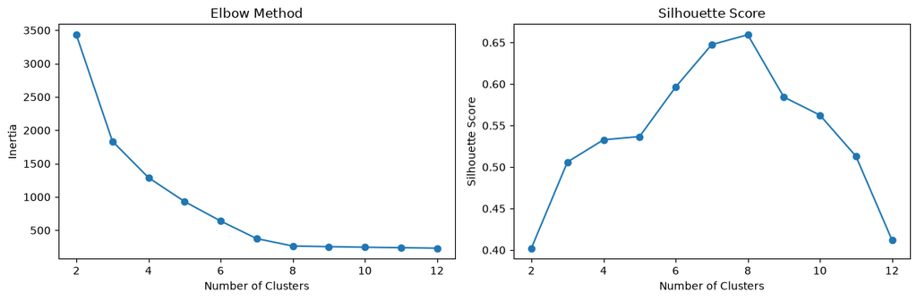

```python
# Visualize cluster evaluation metrics
fig, axes = plt.subplots(1, 2, figsize=(12, 4))

axes[0].plot(
    cluster_evaluation["k"],
    cluster_evaluation["inertia"],
    marker="o"
)
axes[0].set_title("Elbow Method")
axes[0].set_xlabel("Number of Clusters")
axes[0].set_ylabel("Inertia")

axes[1].plot(
    cluster_evaluation["k"],
    cluster_evaluation["silhouette_score"],
    marker="o"
)
axes[1].set_title("Silhouette Score")
axes[1].set_xlabel("Number of Clusters")
axes[1].set_ylabel("Silhouette Score")

plt.tight_layout()
plt.show()
```

**Cluster Selection Summary:** The silhouette score improves as the number of clusters increases from 2 through 8, reaching its highest value at approximately 0.66 for eight clusters before declining for larger solutions. The inertia curve also shows diminishing improvement as the number of clusters approaches this range. Based on the combination of cluster separation and within-cluster compactness, eight clusters were selected for the final model.

### Final Clustering Model

A final KMeans model with eight clusters was fitted to the standardized operating variables. Cluster assignments were then added to the integrated production dataset so that each operating-condition profile could be compared with machine, supplier, batch, and test-outcome information.

```python
# Fit the final eight-cluster model
final_kmeans = KMeans(
    n_clusters=8,
    random_state=42,
    n_init=10
)

cluster_labels = final_kmeans.fit_predict(X_scaled)

# Add cluster assignments to the analysis dataset
dfb = dfb.copy()
dfb["cluster"] = cluster_labels

# Review cluster sizes
cluster_sizes = (
    dfb["cluster"]
       .value_counts()
       .sort_index()
       .rename("observations")
       .to_frame()
)

cluster_sizes
```

| cluster | observations |
| --- | --- |
| 0 | 181 |
| 1 | 166 |
| 2 | 200 |
| 3 | 201 |
| 4 | 190 |
| 5 | 174 |
| 6 | 130 |
| 7 | 170 |

### Operating Profiles by Cluster

Cluster profiles were examined using the original measurement scales of the four operating variables. Comparing cluster-level averages provides an interpretable view of the operating conditions that distinguish each production group.

```python
# Profile each cluster using average operating conditions
cluster_profiles = (
    dfb.groupby("cluster")[["x1", "x2", "x3", "x4"]]
       .mean()
       .round(2)
)

cluster_profiles["observations"] = (
    dfb.groupby("cluster").size()
)

cluster_profiles
```

| cluster | x1 | x2 | x3 | x4 | observations |
| --- | --- | --- | --- | --- | --- |
| 0 | 48.95 | 92.56 | 22.77 | 10.49 | 181 |
| 1 | 55.10 | 110.36 | 25.12 | 8.66 | 166 |
| 2 | 52.91 | 106.39 | 23.98 | 9.58 | 200 |
| 3 | 49.56 | 103.74 | 22.21 | 13.72 | 201 |
| 4 | 52.58 | 99.90 | 20.55 | 11.08 | 190 |
| 5 | 46.85 | 75.07 | 26.61 | 9.39 | 174 |
| 6 | 55.24 | 119.02 | 28.02 | 9.85 | 130 |
| 7 | 55.58 | 111.69 | 23.96 | 11.39 | 170 |

### Test Outcomes by Cluster

Failure rates were compared across the operating-condition clusters to determine whether the naturally occurring production profiles are associated with different product test outcomes.

```python
# Compare test outcomes across operating-condition clusters
cluster_failure_summary = (
    dfb.groupby("cluster")["Result"]
       .agg(
           tested="count",
           passed="sum"
       )
)

cluster_failure_summary["failed"] = (
    cluster_failure_summary["tested"]
    - cluster_failure_summary["passed"]
)

cluster_failure_summary["failure_rate"] = (
    cluster_failure_summary["failed"]
    / cluster_failure_summary["tested"]
)

cluster_failure_summary.round(3)
```

| cluster | tested | passed | failed | failure_rate |
| --- | --- | --- | --- | --- |
| 0 | 181 | 35 | 146 | 0.807 |
| 1 | 166 | 16 | 150 | 0.904 |
| 2 | 200 | 36 | 164 | 0.820 |
| 3 | 201 | 194 | 7 | 0.035 |
| 4 | 190 | 34 | 156 | 0.821 |
| 5 | 174 | 70 | 104 | 0.598 |
| 6 | 130 | 7 | 123 | 0.946 |
| 7 | 170 | 34 | 136 | 0.800 |

**Cluster Outcome Summary:** Test outcomes differ substantially across the eight operating-condition clusters. Cluster 3 has a failure rate of only 3.5%, compared with failure rates above 80% for several other clusters and a maximum of 94.6% for Cluster 6. Cluster 5 also performs comparatively better, with a failure rate of 59.8%.

These results indicate that combinations of machine operating conditions are strongly associated with product test outcomes. Cluster 3 is particularly distinctive, combining moderate values of `x1` and `x2`, relatively low `x3`, and the highest average `x4` value among the eight clusters. Because the clustering model was created without using test outcomes, the substantial differences in failure rates were identified independently of the pass/fail labels.

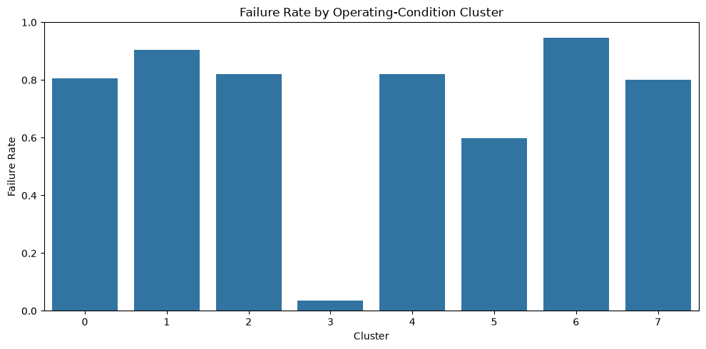

```python
# Visualize failure rates across operating-condition clusters
cluster_failure_plot = (
    cluster_failure_summary
    .reset_index()
)

plt.figure(figsize=(10, 5))

sns.barplot(
    data=cluster_failure_plot,
    x="cluster",
    y="failure_rate"
)

plt.title("Failure Rate by Operating-Condition Cluster")
plt.xlabel("Cluster")
plt.ylabel("Failure Rate")
plt.ylim(0, 1)

plt.tight_layout()
plt.show()
```

### Operating-Condition Profiles

Standardized cluster centers were compared to show how each operating-condition profile differs from the overall production average. Positive values indicate operating conditions above the overall mean, while negative values indicate conditions below the overall mean.

```python
# Calculate standardized operating-condition profiles for each cluster
cluster_centers = pd.DataFrame(
    final_kmeans.cluster_centers_,
    columns=cluster_features
)

cluster_centers.index.name = "cluster"

cluster_centers.round(2)
```

| cluster | x1 | x2 | x3 | x4 |
| --- | --- | --- | --- | --- |
| 0 | -0.95 | -0.73 | -0.53 | -0.07 |
| 1 | 1.02 | 0.68 | 0.54 | -1.26 |
| 2 | 0.31 | 0.36 | 0.02 | -0.66 |
| 3 | -0.76 | 0.15 | -0.78 | 2.03 |
| 4 | 0.21 | -0.15 | -1.53 | 0.31 |
| 5 | -1.63 | -2.10 | 1.21 | -0.78 |
| 6 | 1.06 | 1.36 | 1.84 | -0.49 |
| 7 | 1.17 | 0.78 | 0.01 | 0.51 |

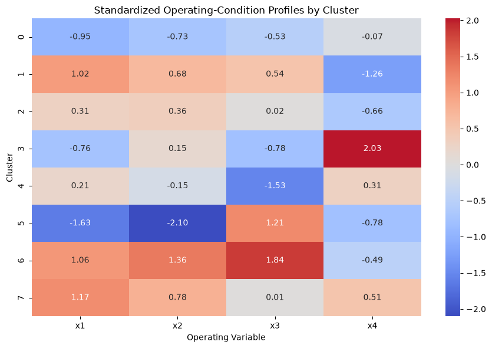

```python
# Visualize standardized operating-condition profiles
plt.figure(figsize=(9, 6))

sns.heatmap(
    cluster_centers,
    annot=True,
    fmt=".2f",
    center=0,
    cmap="coolwarm"
)

plt.title("Standardized Operating-Condition Profiles by Cluster")
plt.xlabel("Operating Variable")
plt.ylabel("Cluster")
plt.tight_layout()
plt.show()
```

**Operating Profile Summary:** The operating-condition profiles reveal substantial differences between clusters with the highest and lowest failure rates. Cluster 3, which has a failure rate of only 3.5%, is characterized by below-average `x1` and `x3`, near-average `x2`, and an exceptionally high `x4` value. In contrast, Cluster 6, with the highest failure rate at 94.6%, has above-average values for `x1`, `x2`, and `x3`, particularly `x3`, while `x4` is below average.

These contrasting profiles suggest that product test outcomes are associated with combinations of operating conditions rather than with any single operating variable in isolation. The cluster results provide a useful starting point for investigating which operating-condition ranges may be associated with more favorable production outcomes.

### Clustering Analysis Summary

The clustering analysis identified eight distinct operating-condition profiles using only the four machine operating variables. Cluster selection was supported by both inertia and silhouette analysis, with the eight-cluster solution achieving the highest silhouette score among the candidate models evaluated.

When test outcomes were examined after clustering, failure rates differed substantially across the resulting groups, ranging from 3.5% in Cluster 3 to 94.6% in Cluster 6. Because test outcomes were not used to create the clusters, these differences provide evidence that naturally occurring combinations of machine operating conditions are meaningfully associated with production performance.

# Key Findings and Operational Implications

This analysis integrated machine operating data, supplier characteristics, production-batch information, and product test results to examine potential drivers of manufacturing performance.

### Key Findings

- **Machine performance was relatively similar overall.** Failure rates ranged from 67.7% to 72.2% across the three machines. Machine 3 had the highest failure rate despite having fewer tested observations, demonstrating the importance of comparing rates rather than raw failure counts.
- **Supplier differences were more nuanced than raw counts suggested.** Supplier A produced more failures in absolute terms because it had more tested observations, while Supplier B had the higher failure rate at 74.5% compared with 67.0% for Supplier A. Supplier A also exhibited substantially greater variability in material density, although average machine operating conditions remained broadly similar across suppliers.
- **Production batch showed the greatest variation in test outcomes.** Batch-level failure rates ranged from 0% to 100%. Several batches experienced either complete failure or no observed failures across multiple machines, suggesting that batch-level characteristics warrant particular attention when investigating production performance.
- **Operating-condition profiles were strongly associated with test outcomes.** Unsupervised clustering identified eight distinct operating profiles with failure rates ranging from 3.5% to 94.6%. The lowest-failure cluster combined below-average `x1` and `x3`, near-average `x2`, and substantially above-average `x4`, while the highest-failure cluster exhibited elevated `x1`, `x2`, and `x3` with below-average `x4`.

### Operational Implications

The results suggest that manufacturing failures are unlikely to be explained by machine or supplier identity alone. Batch-level characteristics and combinations of machine operating conditions appear more closely associated with differences in product test outcomes.

In a production environment, these findings would support further investigation into the characteristics of high- and low-performing batches and the operating-condition ranges represented by the lowest-failure clusters. Additional controlled analysis would be required before treating these relationships as causal or using them to establish production settings.